# Assignment 5

Loading required packages

```r
library(tidyverse)
library(psych)
library(magrittr)
library(vcd)
library(MASS)
library(caret)
library(readr)
```

Question 1a: Step 1. Open “iris” data set

```r
iris <- iris
```

Step 2. Summary statistics for all variables

```r
iris %>%
    describe
```

|  | vars | n | mean | sd | median | trimmed | mad | min | max | range | skew | kurtosis | se |
| --- | --- | --- | --- | --- | --- | --- | --- | --- | --- | --- | --- | --- | --- |
| Sepal.Length | 1 | 150 | 5.84 | 0.83 | 5.80 | 5.81 | 1.04 | 4.3 | 7.9 | 3.6 | 0.31 | -0.61 | 0.07 |
| Sepal.Width | 2 | 150 | 3.06 | 0.44 | 3.00 | 3.04 | 0.44 | 2.0 | 4.4 | 2.4 | 0.31 | 0.14 | 0.04 |
| Petal.Length | 3 | 150 | 3.76 | 1.77 | 4.35 | 3.76 | 1.85 | 1.0 | 6.9 | 5.9 | -0.27 | -1.42 | 0.14 |
| Petal.Width | 4 | 150 | 1.20 | 0.76 | 1.30 | 1.18 | 1.04 | 0.1 | 2.5 | 2.4 | -0.10 | -1.36 | 0.06 |
| Species* | 5 | 150 | 2.00 | 0.82 | 2.00 | 2.00 | 1.48 | 1.0 | 3.0 | 2.0 | 0.00 | -1.52 | 0.07 |

```r
table(iris$Species)
```

```
    setosa versicolor  virginica
        50         50         50
```

From table 1 we can determine that there were 150 flower observations, and no missing data. Table 2 indicates that there were 50 observations of each of the 3 species: setosa, versicolor, and virginica. This is a factor variable, thus setosa = 1, versicolor = 2, and virginica = 3 in the code. Skewness and kurtosis statistics are acceptable for all continuous variables, suggesting normal distribution. An examination of minimum and maximum variables do not indicate values that are likely to be false (due to an impossible size)

Step 3. Check distribution of continuous variables by Species, to establish multivariate normality (IVs must be normally distributed at each level of the grouping variable, i.e.: species)

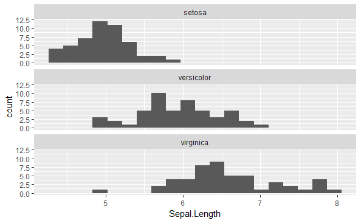

```r
ggplot(data = iris, mapping = aes(x = Sepal.Length))+
  geom_histogram(bins = 20)+
  facet_wrap(~Species, nrow =3)
```

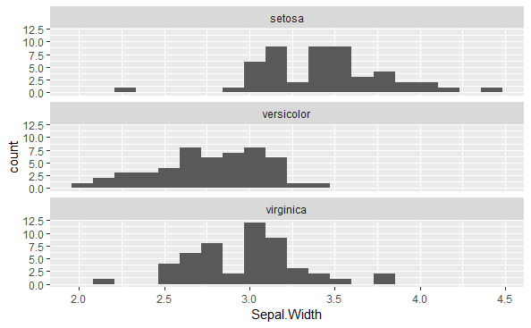

```r
ggplot(data = iris, mapping = aes(x = Sepal.Width))+
  geom_histogram(bins = 20)+
  facet_wrap(~Species, nrow = 3)
```

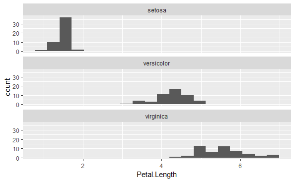

```r
ggplot(data = iris, mapping = aes(x = Petal.Length))+
  geom_histogram(bins = 20)+
  facet_wrap(~Species, nrow = 3)
```

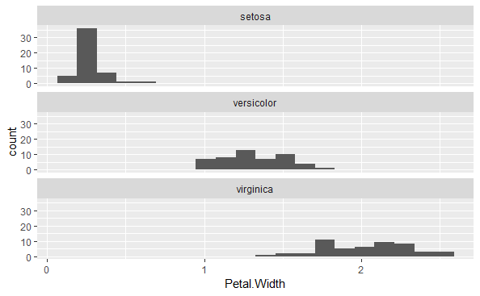

```r
ggplot(data = iris, mapping = aes(x = Petal.Width))+
  geom_histogram(bins = 20)+
  facet_wrap(~Species, nrow = 3)
```

All variables look fairly normally distributed within each species. Linear discriminant analysis is also robust to slight violations of multivariate normality. Each of the 150 obsertvations is of a seperate flower, thus cases are independent.

Step 4. Check grouped distributions with summary stats, where skewness and kurtosis are reported by group.

```r
describeBy(iris, group = iris$Species)
```

```
 Descriptive statistics by group
group: setosa
```

|  | vars | n | mean | sd | median | trimmed | mad | min | max | range | skew | kurtosis | se |
| --- | --- | --- | --- | --- | --- | --- | --- | --- | --- | --- | --- | --- | --- |
| Sepal.Length | 1 | 50 | 5.01 | 0.35 | 5.0 | 5.00 | 0.30 | 4.3 | 5.8 | 1.5 | 0.11 | -0.45 | 0.05 |
| Sepal.Width | 2 | 50 | 3.43 | 0.38 | 3.4 | 3.42 | 0.37 | 2.3 | 4.4 | 2.1 | 0.04 | 0.60 | 0.05 |
| Petal.Length | 3 | 50 | 1.46 | 0.17 | 1.5 | 1.46 | 0.15 | 1.0 | 1.9 | 0.9 | 0.10 | 0.65 | 0.02 |
| Petal.Width | 4 | 50 | 0.25 | 0.11 | 0.2 | 0.24 | 0.00 | 0.1 | 0.6 | 0.5 | 1.18 | 1.26 | 0.01 |
| Species* | 5 | 50 | 1.00 | 0.00 | 1.0 | 1.00 | 0.00 | 1.0 | 1.0 | 0.0 | NaN | NaN | 0.00 |

```
------------------------------------------------------
group: versicolor
```

|  | vars | n | mean | sd | median | trimmed | mad | min | max | range | skew | kurtosis | se |
| --- | --- | --- | --- | --- | --- | --- | --- | --- | --- | --- | --- | --- | --- |
| Sepal.Length | 1 | 50 | 5.94 | 0.52 | 5.90 | 5.94 | 0.52 | 4.9 | 7.0 | 2.1 | 0.10 | -0.69 | 0.07 |
| Sepal.Width | 2 | 50 | 2.77 | 0.31 | 2.80 | 2.78 | 0.30 | 2.0 | 3.4 | 1.4 | -0.34 | -0.55 | 0.04 |
| Petal.Length | 3 | 50 | 4.26 | 0.47 | 4.35 | 4.29 | 0.52 | 3.0 | 5.1 | 2.1 | -0.57 | -0.19 | 0.07 |
| Petal.Width | 4 | 50 | 1.33 | 0.20 | 1.30 | 1.32 | 0.22 | 1.0 | 1.8 | 0.8 | -0.03 | -0.59 | 0.03 |
| Species* | 5 | 50 | 2.00 | 0.00 | 2.00 | 2.00 | 0.00 | 2.0 | 2.0 | 0.0 | NaN | NaN | 0.00 |

```
------------------------------------------------------
group: virginica
```

|  | vars | n | mean | sd | median | trimmed | mad | min | max | range | skew | kurtosis | se |
| --- | --- | --- | --- | --- | --- | --- | --- | --- | --- | --- | --- | --- | --- |
| Sepal.Length | 1 | 50 | 6.59 | 0.64 | 6.50 | 6.57 | 0.59 | 4.9 | 7.9 | 3.0 | 0.11 | -0.20 | 0.09 |
| Sepal.Width | 2 | 50 | 2.97 | 0.32 | 3.00 | 2.96 | 0.30 | 2.2 | 3.8 | 1.6 | 0.34 | 0.38 | 0.05 |
| Petal.Length | 3 | 50 | 5.55 | 0.55 | 5.55 | 5.51 | 0.67 | 4.5 | 6.9 | 2.4 | 0.52 | -0.37 | 0.08 |
| Petal.Width | 4 | 50 | 2.03 | 0.27 | 2.00 | 2.03 | 0.30 | 1.4 | 2.5 | 1.1 | -0.12 | -0.75 | 0.04 |
| Species* | 5 | 50 | 3.00 | 0.00 | 3.00 | 3.00 | 0.00 | 3.0 | 3.0 | 0.0 | NaN | NaN | 0.00 |

Table 2 = setosa, table 3 = versicolor, and table 4 = virginica All skewness and kurtosis values are acceptable, suggesting normal distribution of each variable for each species. Setosa have the lowest mean sepal length (m = 5.01, SD = 0.35), followed by versicolor (m = 5.94, SD = 0.52), and then virginica (m = 6.59, SD = 0.64). Setosa have the highest mean sepal width(m = 3.43, SD = 0.38), followed by virginica (m = 2.97, SD = 0.32), and then versicolor (m = 2.77, SD = 0.31), although the latter two have very similar means. This creates the impression that setosa have shorter, broader sepals, versicolor have longer, narrower sepals, and virginica have even longer sepals that are of similar bredth to versicolor sepals. Setosa have the lowest mean petal length (m = 1.46, SD = 0.17), followed by versicolor (m = 4.26, SD = 0.47), and then virginica (m = 5.55, SD = 0.55) Setosa also have the lowest mean petal width (m = 0.25, SD = 11), followed by versicolor (m = 1.33, SD = 0.20), and virginica (m = 2.03, SD = 0.27) So the setosa have the smallest petals (shortest and narrowest), followed by versicolor, and then virginica. In general, the flowers tend to ascend in size: setosa, versicolor, virginica (respectively). But whilst the petals get longer and broader, the sepals get longer and thinner.

Step 5. check the relationship between each aspect of flower measurement and species

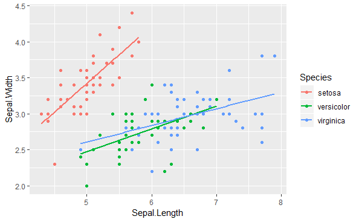

```r
ggplot(data = iris, mapping = aes(x = Sepal.Length, y = Sepal.Width, color = Species))+
  geom_point()+
  geom_smooth(method = "lm", se = FALSE)
```

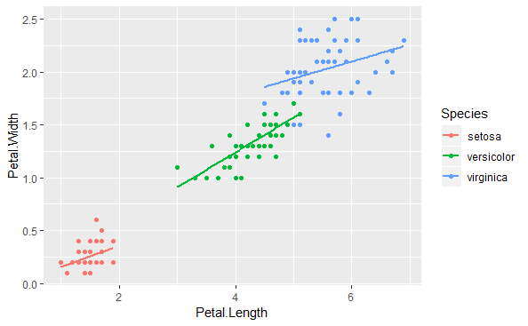

```r
ggplot(data = iris, mapping = aes(x = Petal.Length, y = Petal.Width, color = Species))+
  geom_point()+
  geom_smooth(method = "lm", se = FALSE)
```

Graph 1 depicts the sepals in terms of length and width by species. As suggested by the summary, Setosa have distinctive short, broad petals. Versiocolor and Virginica have some overlap in the appearance of their sepals. Versicolor sepals are typically narrower than Setosa sepals, although there is a fair amount if overlap in sepal length. Virginica tend to have longer sepals than Setosa do, although there is a fair amount of overlap in sepal width. All sepals get wider as they get longer. Graph 2 depicts the petals in terms of length and width by species. The petal characteristics for each species are much more distinct than the sepal characteristics. As suggested by the summary statistics, petal size (length and width) increases across the species in the order: setosa, versicolor, virginica.

Step 6. Due to the seemingly interactive nature of the two measurements for each part of the plant, it may be useful to see how the interaction of length and width for the sepals and petals correlate with species

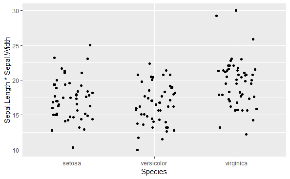

```r
ggplot(data = iris, mapping = aes(x = Species, y = Sepal.Length*Sepal.Width))+
  geom_jitter(height = 0, width = 0.25)+
  geom_smooth(se = FALSE)
```

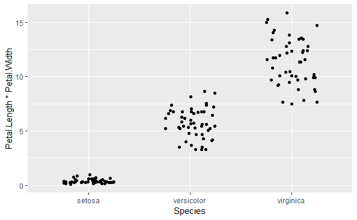

```r
ggplot(data = iris, mapping = aes(x = Species, y = Petal.Length*Petal.Width))+
  geom_jitter(height = 0, width = 0.25)+
  geom_smooth(se = FALSE)
```

```r
NA
```

Whilst the sepal size (Graph 1) does not produce a clear pattern, petal size (Graph 2) clearly depitcs the ascending size pattern noted earlier.

Question 1b Run a linear discriminant analysis to predict species, using the 4 variables in the data

```r
ldamodel1 <-lda(Species ~ Sepal.Length + Sepal.Width + Petal.Length + Petal.Width, data = iris)
ldamodel1
```

```
Call:
lda(Species ~ Sepal.Length + Sepal.Width + Petal.Length + Petal.Width,
    data = iris)

Prior probabilities of groups:
    setosa versicolor  virginica
 0.3333333  0.3333333  0.3333333

Group means:
           Sepal.Length Sepal.Width Petal.Length Petal.Width
setosa            5.006       3.428        1.462       0.246
versicolor        5.936       2.770        4.260       1.326
virginica         6.588       2.974        5.552       2.026

Coefficients of linear discriminants:
                    LD1         LD2
Sepal.Length  0.8293776  0.02410215
Sepal.Width   1.5344731  2.16452123
Petal.Length -2.2012117 -0.93192121
Petal.Width  -2.8104603  2.83918785

Proportion of trace:
   LD1    LD2
0.9912 0.0088
```

The prior probabilities of the groups confirm an equal number of observations were conducted for each species (one third of the total observations)

Question 1c: USe confusion matrix to compute success rate

```r
ldamodel1predict <- predict(ldamodel1)
confusionMatrix(ldamodel1predict$class, iris$Species)
```

```
Confusion Matrix and Statistics

            Reference
Prediction   setosa versicolor virginica
  setosa         50          0         0
  versicolor      0         48         1
  virginica       0          2        49

Overall Statistics

               Accuracy : 0.98
                 95% CI : (0.9427, 0.9959)
    No Information Rate : 0.3333
    P-Value [Acc > NIR] : < 2.2e-16

                  Kappa : 0.97
 Mcnemar's Test P-Value : NA

Statistics by Class:

                     Class: setosa Class: versicolor Class: virginica
Sensitivity                 1.0000            0.9600           0.9800
Specificity                 1.0000            0.9900           0.9800
Pos Pred Value              1.0000            0.9796           0.9608
Neg Pred Value              1.0000            0.9802           0.9899
Prevalence                  0.3333            0.3333           0.3333
Detection Rate              0.3333            0.3200           0.3267
Detection Prevalence        0.3333            0.3267           0.3400
Balanced Accuracy           1.0000            0.9750           0.9800
```

The accuracy of this model is 0.98, meaning that this model can predict the species correctly from the plant part ratios (the variables) 98% of the time. The no information rate is 0.3333, meaning that with no information, the species would be correctly identified 33% of the time (by chance). Adding these 4 predictors improves the model by 65%. The 4 variable model is very good (and highly significant, p < 0.001): - it classified all cases of setosa correctly (as was suggested by the exploratory plots - where setosa was the most distinct in terms of both sepals and petals) - it only classified 2 cases of versicolor as virginica, and one case of virginica as versicolor (which could be expected, as there was an overlap in the sepal characteristics of these 2 species)

QUestion 1d. Use the plotting methods built into LDA in MASS to explore the adequacy of the classification. What do they tell you?

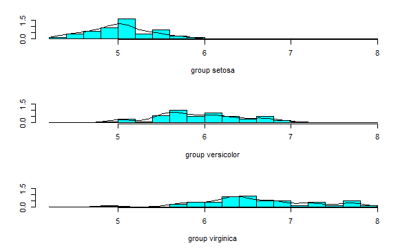

```r
ldahist(iris$Sepal.Length, iris$Species, type = "both")
```

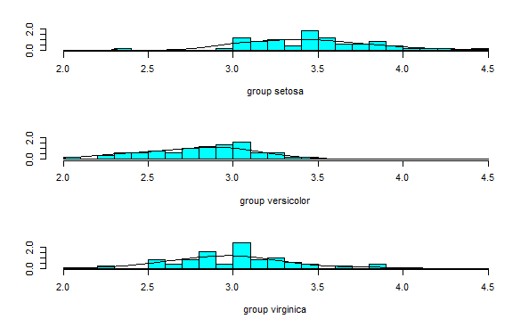

```r
ldahist(iris$Sepal.Width, iris$Species, type = "both")
```

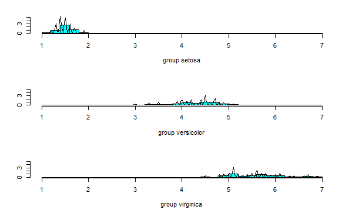

```r
ldahist(iris$Petal.Length, iris$Species, type = "both")
```

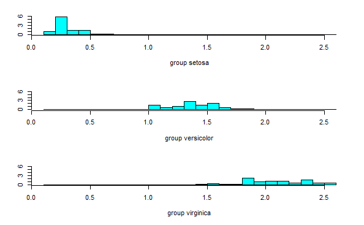

```r
ldahist(iris$Petal.Width, iris$Species, type = "histogram")
```

Question 1e: Use cross validation in lda and compare classification rate success Start by creating a vector of 113 random numbers ranging from 1 to 150 (113/150 observations is roughly 75%) Next, randomly select a subset of 113 cases from the data set to be analysed as a training sample

```r
random113 <- sample(1:150, 113, replace = FALSE)
ldamodel2 <-lda(Species ~ Sepal.Length + Sepal.Width + Petal.Length + Petal.Width, data = iris, subset = random113)
ldamodel2
```

```
Call:
lda(Species ~ Sepal.Length + Sepal.Width + Petal.Length + Petal.Width,
    data = iris, subset = random113)

Prior probabilities of groups:
    setosa versicolor  virginica
 0.3628319  0.2920354  0.3451327

Group means:
           Sepal.Length Sepal.Width Petal.Length Petal.Width
setosa         4.997561    3.387805     1.485366   0.2512195
versicolor     5.869697    2.742424     4.200000   1.3151515
virginica      6.558974    2.958974     5.520513   2.0076923

Coefficients of linear discriminants:
                   LD1         LD2
Sepal.Length  0.808222  0.04407395
Sepal.Width   1.779852  2.27073949
Petal.Length -2.337942 -0.67004429
Petal.Width  -2.803785  2.20356942

Proportion of trace:
   LD1    LD2
0.9936 0.0064
```

```r
ldamodel2predict <- predict(ldamodel2)
confusionMatrix(ldamodel2predict$class, iris$Species[random113])
```

```
Confusion Matrix and Statistics

            Reference
Prediction   setosa versicolor virginica
  setosa         41          0         0
  versicolor      0         32         1
  virginica       0          1        38

Overall Statistics

               Accuracy : 0.9823
                 95% CI : (0.9375, 0.9978)
    No Information Rate : 0.3628
    P-Value [Acc > NIR] : < 2.2e-16

                  Kappa : 0.9733
 Mcnemar's Test P-Value : NA

Statistics by Class:

                     Class: setosa Class: versicolor Class: virginica
Sensitivity                 1.0000            0.9697           0.9744
Specificity                 1.0000            0.9875           0.9865
Pos Pred Value              1.0000            0.9697           0.9744
Neg Pred Value              1.0000            0.9875           0.9865
Prevalence                  0.3628            0.2920           0.3451
Detection Rate              0.3628            0.2832           0.3363
Detection Prevalence        0.3628            0.2920           0.3451
Balanced Accuracy           1.0000            0.9786           0.9804
```

```r
random37 <- sample(1:150, 150, replace = FALSE) - random113
```

```
longer object length is not a multiple of shorter object length
```

I’m not sure how to compare this to a test set. I will therefore use traditional training and test sets

```r
# Build the training and test data sets
set.seed(2)
iristraindata <- sample_frac(iris, 0.75)
iristestdata  <- dplyr::setdiff(iris, iristraindata)
# Build the lda model on the training data set
ldamodeltrain <- lda(Species ~ Sepal.Length + Sepal.Width + Petal.Length + Petal.Width, data = iristraindata)
# Generate an LDA prediction object of traindata
ldamodeltrainpred <- predict(ldamodeltrain)
# Generate a confusion matrix for training set
confusionMatrix(as.factor(ldamodeltrainpred$class), as.factor(iristraindata$Species),
                positive = c("1"))
```

```
Confusion Matrix and Statistics

            Reference
Prediction   setosa versicolor virginica
  setosa         38          0         0
  versicolor      0         39         0
  virginica       0          1        34

Overall Statistics

               Accuracy : 0.9911
                 95% CI : (0.9513, 0.9998)
    No Information Rate : 0.3571
    P-Value [Acc > NIR] : < 2.2e-16

                  Kappa : 0.9866
 Mcnemar's Test P-Value : NA

Statistics by Class:

                     Class: setosa Class: versicolor Class: virginica
Sensitivity                 1.0000            0.9750           1.0000
Specificity                 1.0000            1.0000           0.9872
Pos Pred Value              1.0000            1.0000           0.9714
Neg Pred Value              1.0000            0.9863           1.0000
Prevalence                  0.3393            0.3571           0.3036
Detection Rate              0.3393            0.3482           0.3036
Detection Prevalence        0.3393            0.3482           0.3125
Balanced Accuracy           1.0000            0.9875           0.9936
```

```r
# Generate an LDA prediction object of testdata
ldamodeltestpred <- predict(ldamodeltrain,
                            newdata = iristestdata)
# Generate a confusion matrix for test set
confusionMatrix(as.factor(ldamodeltestpred$class), as.factor(iristestdata$Species),
                positive = c("1"))
```

```
Confusion Matrix and Statistics

            Reference
Prediction   setosa versicolor virginica
  setosa         12          0         0
  versicolor      0          9         1
  virginica       0          1        15

Overall Statistics

               Accuracy : 0.9474
                 95% CI : (0.8225, 0.9936)
    No Information Rate : 0.4211
    P-Value [Acc > NIR] : 7.335e-12

                  Kappa : 0.9195
 Mcnemar's Test P-Value : NA

Statistics by Class:

                     Class: setosa Class: versicolor Class: virginica
Sensitivity                 1.0000            0.9000           0.9375
Specificity                 1.0000            0.9643           0.9545
Pos Pred Value              1.0000            0.9000           0.9375
Neg Pred Value              1.0000            0.9643           0.9545
Prevalence                  0.3158            0.2632           0.4211
Detection Rate              0.3158            0.2368           0.3947
Detection Prevalence        0.3158            0.2632           0.4211
Balanced Accuracy           1.0000            0.9321           0.9460
```

THe train data (on which we built the model) has an accuracy of 0.9911, thus in about 99% of cases the model correctly predicts iris species. The test data has an accuracy of 0.9474, thus in about 95% of cases the model correctly predicts iris species. A slight drop in accuracy is to be expected, but the model is still very good and highly significant (p < 0.001)

Question 1f. Repeat a quadratic discriminant analysis for the model, and include accuracy rate from confusion matrix

```r
qdamodel1 <-qda(Species ~ Sepal.Length + Sepal.Width + Petal.Length + Petal.Width, data = iris)
qdamodel1
```

```
Call:
qda(Species ~ Sepal.Length + Sepal.Width + Petal.Length + Petal.Width,
    data = iris)

Prior probabilities of groups:
    setosa versicolor  virginica
 0.3333333  0.3333333  0.3333333

Group means:
           Sepal.Length Sepal.Width Petal.Length Petal.Width
setosa            5.006       3.428        1.462       0.246
versicolor        5.936       2.770        4.260       1.326
virginica         6.588       2.974        5.552       2.026
```

```r
qdamodel1predict <- predict(qdamodel1)
confusionMatrix(qdamodel1predict$class, iris$Species)
```

```
Confusion Matrix and Statistics

            Reference
Prediction   setosa versicolor virginica
  setosa         50          0         0
  versicolor      0         48         1
  virginica       0          2        49

Overall Statistics

               Accuracy : 0.98
                 95% CI : (0.9427, 0.9959)
    No Information Rate : 0.3333
    P-Value [Acc > NIR] : < 2.2e-16

                  Kappa : 0.97
 Mcnemar's Test P-Value : NA

Statistics by Class:

                     Class: setosa Class: versicolor Class: virginica
Sensitivity                 1.0000            0.9600           0.9800
Specificity                 1.0000            0.9900           0.9800
Pos Pred Value              1.0000            0.9796           0.9608
Neg Pred Value              1.0000            0.9802           0.9899
Prevalence                  0.3333            0.3333           0.3333
Detection Rate              0.3333            0.3200           0.3267
Detection Prevalence        0.3333            0.3267           0.3400
Balanced Accuracy           1.0000            0.9750           0.9800
```

This quadratic discriminant analysis has the same high accuracy (0.98) as the linear discriminant analysis, and it has the same significance. THis confirms that the model is linear and not quadratic, as adding the option for a quadratic distribution did not improve the model. _____________________________________________________________________ Question 2: Load data set titanic3.xls

```r
titanic<- read_excel("../data/titanic3.xls")
```

```
Coercing text to numeric in M1306 / R1306C13: '328'
```

Question 2a: split data into training and test sets

```r
# Build the training and test data sets
set.seed(2)
titanictraindata <- sample_frac(titanic, 0.75)
titanictestdata  <- dplyr::setdiff(titanic, titanictraindata)
```

VARIABLE DESCRIPTIONS: pclass Passenger Class (1 = 1st; 2 = 2nd; 3 = 3rd) survival Survival (0 = No; 1 = Yes) sex Sex age Age sibsp Number of Siblings/Spouses Aboard parch Number of Parents/Children Aboard fare Passenger Fare

```r
titanictraindata$survived_fact <- as.factor(titanictraindata$survived)
qdatitanicmodel1 <- qda(survived_fact ~ pclass + as.factor(sex) + sibsp + parch, data = titanictraindata)
qdatitanicmodel1
```

```
Call:
qda(survived_fact ~ pclass + as.factor(sex) + sibsp + parch,
    data = titanictraindata)

Prior probabilities of groups:
        0         1
0.6089613 0.3910387

Group means:
    pclass as.factor(sex)male     sibsp     parch
0 2.513378          0.8377926 0.5217391 0.3444816
1 1.945312          0.3333333 0.4348958 0.4713542
```

```r
qdatitanicmodel1predict <- predict(qdatitanicmodel1)
confusionMatrix(qdatitanicmodel1predict$class, titanictraindata$survived_fact)
```

```
Confusion Matrix and Statistics

          Reference
Prediction   0   1
         0 523 137
         1  75 247

               Accuracy : 0.7841
                 95% CI : (0.757, 0.8095)
    No Information Rate : 0.609
    P-Value [Acc > NIR] : < 2.2e-16

                  Kappa : 0.5332
 Mcnemar's Test P-Value : 2.796e-05

            Sensitivity : 0.8746
            Specificity : 0.6432
         Pos Pred Value : 0.7924
         Neg Pred Value : 0.7671
             Prevalence : 0.6090
         Detection Rate : 0.5326
   Detection Prevalence : 0.6721
      Balanced Accuracy : 0.7589

       'Positive' Class : 0
```

This model has an accuracy rate of 78%

Question 2b:

Test your model on the test set by computing and comparing MSE train and MSE test. (5) c. Re-run the analysis above (i.e. split the dataset into training and test sets, use the model you developed in a) and b) to compute MSE of the model as applied to the test set only), 1000 times (inside a loop). Gather the accuracy rates and plot them as a histogram. What do you conclude? (10) d. Conduct LOOCV using the cv.glm function (in package boot). Note the cost function that you need to use. How does the result compare to what you found in b)? (10) e. Conduct 2 fold, 5 fold, and 10 fold cross validation using the cv.glm function. Set the random seed to 199 so that results are replicable. How do the results compare to what you found in c), b), and a)? (10)